# DNA methylation: Global methylation

Ryan Corbett

This script compares mean beta values from DNA methylation arrays (an estimate of relative global DNA methylation levels) between P-LP carriers and non-carriers within histology groups

Load libraries

```r
suppressPackageStartupMessages({
  library(ggplot2)
  library(tidyverse)
  library(ggpubr)
  library(ggrepel)
})

# Set up directories
root_dir <- rprojroot::find_root(rprojroot::has_dir(".git"))

data_dir <- file.path(root_dir, "data")
analysis_dir <- file.path(root_dir, "analyses", "methylation")
input_dir <- file.path(analysis_dir, "input")
results_dir <- file.path(analysis_dir, "results")
plot_dir <- file.path(analysis_dir, "plots")

# If the directory does not exist, create it
if (!dir.exists(results_dir)) {
  dir.create(results_dir, recursive = TRUE)
}

# source publication theme
source(file.path(root_dir, "figures", "theme.R"))

# set seed to reproduce plots
set.seed(2024)
```

Set input file paths

```r
plp_file <- file.path(data_dir,
                      "pbta-merged-plp-variants-autogvp-abridged.tsv")

plp_lowVAF_file <- file.path(data_dir,
                             "pbta-merged-plp-variants-autogvp-abridged-lowVAF-cpgs.tsv")

plp_sv_file <- file.path(data_dir,
                         "pbta_germline_svs.tsv")

hist_file <- file.path(results_dir,
                       "germline-primary-plus-tumor-histologies-methylation.tsv")

methyl_file <- file.path(results_dir,
                         "pbta-germline-mean-sample-methyl-beta.tsv")

cpg_file <- file.path(root_dir, "analyses", "oncokb-annotation", "input", "cpg.txt")

tmb_file <- file.path(data_dir, "snv-mutation-tmb-coding.tsv")
```

Wrangle data, add histology annotation to methyl df

```r
hist <- read_tsv(hist_file) %>%
  dplyr::mutate(plot_group = case_when(
    plot_group == "Atypical Teratoid Rhabdoid Tumor" ~ "ATRT",
    TRUE ~ plot_group
  ))
methyl <- read_tsv(methyl_file) %>%
  dplyr::filter(Kids_First_Biospecimen_ID_methyl %in% hist$Kids_First_Biospecimen_ID_methyl) %>%
  left_join(hist %>% dplyr::select("Kids_First_Biospecimen_ID_methyl",
                                   "Kids_First_Biospecimen_ID_normal",
                                   "Kids_First_Biospecimen_ID_tumor",
                                   "plot_group", "plot_group_hex",
                                   "molecular_subtype"))
```

Plot mean methylation by histology

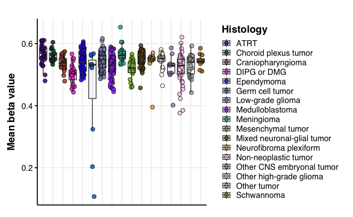

```r
plot_group_palette <- methyl$plot_group_hex
names(plot_group_palette) <- methyl$plot_group

methyl %>%
  ggplot(aes(x = plot_group, y = mean_beta_value, fill = plot_group)) +
  geom_jitter(aes(fill = plot_group), shape = 21, width = 0.2, size = 2.5, alpha = 0.85) +
  geom_boxplot(alpha = 0.05, outlier.shape = NA) +
  labs(x = NULL, y = "Mean beta value", fill = "Histology") +
#  ylim(c(-4, 5)) +
   scale_fill_manual(values = plot_group_palette,
                      breaks = sort(names(plot_group_palette))) +
  theme_Publication() +
    theme(axis.title.x=element_blank(),
        axis.text.x=element_blank(),
        axis.ticks.x=element_blank())

ggsave(file.path(plot_dir, "mean-sample-methyl-beta-by-histology.pdf"),
       width = 8, height = 4, units = "in")
```

Load P-LP files and filter for CPGs

```r
cpgs <- read_lines(cpg_file)

# Load abridged P-LP file and append variant coordinates
germline <- read_tsv(plp_file) %>%
  bind_rows(read_tsv(plp_lowVAF_file)) %>%
  dplyr::filter(Kids_First_Biospecimen_ID_normal %in% hist$Kids_First_Biospecimen_ID_normal) %>%
  dplyr::rename(Hugo_Symbol = gene_symbol_vep) %>%
  dplyr::filter(Hugo_Symbol %in% cpgs)
germline_sv <- read_tsv(plp_sv_file) %>%
  dplyr::rename(Hugo_Symbol = Hugo_Symbol_cpg)
```

Define P-LP carrier status in `methyl`, and plot mean beta values by hist and P-LP carrier status

[figure not shown]

```r
methyl <- methyl %>%
  dplyr::mutate(germline_plp = case_when(
    Kids_First_Biospecimen_ID_normal %in% c(germline$Kids_First_Biospecimen_ID_normal,
                                            germline_sv$Kids_First_Biospecimen_ID_normal) ~ "Yes",
    TRUE ~ "No"
  ))

methyl %>%
  dplyr::filter(plot_group != "Other CNS embryonal tumor") %>%
  ggplot(aes(x = germline_plp, y = mean_beta_value)) +
  geom_jitter(aes(fill = plot_group),
              shape = 21, width = 0.2,
              size = 2.5, alpha = 0.85,
              show.legend = FALSE) +
  geom_boxplot(alpha = 0.05, outlier.shape = NA,
               show.legend = FALSE) +
  stat_compare_means(method = "wilcox",
                     comparisons = list(c("Yes", "No")),
                     method.args = list(alternative = "two.sided")) +
  labs(x = "Germline P/LP variant", y = "Mean beta value", fill = "Histology") +
  facet_wrap(~plot_group, nrow = 4, scale = "free_y",
              labeller = labeller(plot_group = label_wrap_gen(16))) +
   scale_fill_manual(values = plot_group_palette,
                      breaks = sort(names(plot_group_palette))) +
  scale_y_continuous(expand = expansion(mult = .2)) +
  theme_Publication()

ggsave(file.path(plot_dir, "mean-sample-methyl-beta-by-histology-plp.pdf"),
       width = 12, height = 10, units = "in")
```

Extract histology-gene pairs to perform pairwise comparisons of beta values

```r
plp_summary <- germline %>%
  dplyr::select(Kids_First_Biospecimen_ID_normal, Hugo_Symbol) %>%
  bind_rows(germline_sv %>% dplyr::select(Kids_First_Biospecimen_ID_normal, Hugo_Symbol)) %>%
  distinct(Kids_First_Biospecimen_ID_normal, Hugo_Symbol, .keep_all = TRUE) %>%
  dplyr::mutate(plp = "Yes")

gene_groups <- plp_summary %>%
  left_join(hist[c("Kids_First_Biospecimen_ID_normal", "plot_group")]) %>%
  group_by(Hugo_Symbol, plot_group) %>%
  summarise(n = n()) %>%
  dplyr::filter(n >= 2) %>%
  dplyr::mutate(gene_group = glue::glue("{Hugo_Symbol}: {plot_group}"))
```

Plot mean methylation by histology and P-LP carrier status for genes with n>=2 in hist group

[figure not shown]

```r
methyl <- methyl %>%
  left_join(gene_groups[,c("Hugo_Symbol", "plot_group", "gene_group")],
            by = "plot_group") %>%
  left_join(plp_summary, by = c("Kids_First_Biospecimen_ID_normal", "Hugo_Symbol")) %>%
  dplyr::mutate(plp = case_when(
    plp == "Yes" ~ "Yes",
    TRUE ~ "No"
  )) %>%
  distinct()
methyl %>%
  dplyr::filter(!is.na(gene_group)) %>%
  ggplot(aes(x = plp, y = mean_beta_value)) +
  geom_jitter(aes(fill = plot_group),
              shape = 21, width = 0.2,
              size = 2.5, alpha = 0.85,
              show.legend = FALSE) +
  geom_boxplot(alpha = 0.05, outlier.shape = NA,
               show.legend = FALSE) +
  stat_compare_means(method = "wilcox",
                     comparisons = list(c("Yes", "No")),
                     method.args = list(alternative = "two.sided")) +
  labs(x = "Germline P/LP variant", y = "Mean beta value", fill = "Histology") +
  ylim(c(0.35,0.7)) +
  facet_wrap(~gene_group, nrow = 4,
             labeller = labeller(gene_group = label_wrap_gen(16))) +
   scale_fill_manual(values = plot_group_palette,
                      breaks = sort(names(plot_group_palette))) +
  theme_Publication()

ggsave(file.path(plot_dir, "mean-sample-methyl-beta-by-hist-gene-plp.pdf"),
       width = 16, height = 10, units = "in")
```

Plot mean beta values by histology and P-LP status in DNA repair genes and specific DNA repair pathway gene lists

```r
repair_genes <- read_lines(file.path(root_dir, "analyses",
                                     "dna-repair-variant-summary", "input",
                                     "Knijnenburg_paper", "dna_repair_all.txt"))
mmr_genes <- read_lines(file.path(root_dir, "analyses",
                                     "dna-repair-variant-summary", "input",
                                     "Knijnenburg_paper", "mismatch_repair.txt"))
hr_genes <- read_lines(file.path(root_dir, "analyses",
                                     "dna-repair-variant-summary", "input",
                                     "Knijnenburg_paper", "homologous_recombination.txt"))
ber_genes <- read_lines(file.path(root_dir, "analyses",
                                     "dna-repair-variant-summary", "input",
                                     "Knijnenburg_paper", "base_excision_repair.txt"))
ner_genes <- read_lines(file.path(root_dir, "analyses",
                                     "dna-repair-variant-summary", "input",
                                     "Knijnenburg_paper", "nucleotide_excision_repair.txt"))
nhej_genes <- read_lines(file.path(root_dir, "analyses",
                                     "dna-repair-variant-summary", "input",
                                     "Knijnenburg_paper", "nonhomologous_end_joining.txt"))

repair_list <- list("DNA repair" = repair_genes, "MMR" = mmr_genes, "HR" = hr_genes,
                    "BER" = ber_genes, "NER" = ner_genes, "NHEJ" = nhej_genes)

for (each in names(repair_list)){

  methyl %>%
    distinct(Kids_First_Biospecimen_ID_normal, .keep_all = TRUE) %>%
    dplyr::mutate(repair_plp = case_when(
      Kids_First_Biospecimen_ID_normal %in% plp_summary$Kids_First_Biospecimen_ID_normal[plp_summary$Hugo_Symbol %in% repair_list[[each]]] ~ "Yes",
      TRUE ~ "No"
    )) %>%
    ggplot(aes(x = repair_plp, y = mean_beta_value)) +
    geom_jitter(aes(fill = plot_group),
                shape = 21, width = 0.2,
                size = 2.5, alpha = 0.85,
                show.legend = FALSE) +
    geom_boxplot(alpha = 0.05, outlier.shape = NA,
                 show.legend = FALSE) +
    stat_compare_means(method = "wilcox",
                       comparisons = list(c("Yes", "No")),
                       method.args = list(alternative = "two.sided")) +
    labs(x = glue::glue("{each} gene P/LP variant"), y = "Mean beta value z-score", fill = "Histology") +
    ylim(c(0.35,.7)) +
     scale_fill_manual(values = plot_group_palette,
                        breaks = sort(names(plot_group_palette))) +
    facet_wrap(~plot_group, nrow = 4,
               labeller = labeller(plot_group = label_wrap_gen(16))) +
    theme_Publication()

ggsave(file.path(plot_dir,
                 glue::glue("global-beta-value-{each}-plp-vs-other.pdf")),
       height = 9, width = 10, units = "in")

}
```

Plot mean methylation in H3-wt HGG by MMR P/LP carrier status

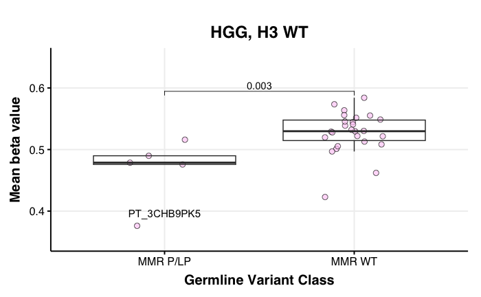

```r
methyl %>%
  distinct(Kids_First_Biospecimen_ID_normal, .keep_all = TRUE) %>%
  dplyr::filter(plot_group == "Other high-grade glioma",
                grepl("wildtype", molecular_subtype)) %>%
  dplyr::mutate(MMR_plp = case_when(
    Kids_First_Biospecimen_ID_normal %in% plp_summary$Kids_First_Biospecimen_ID_normal[plp_summary$Hugo_Symbol %in% mmr_genes] ~ "MMR P/LP",
    TRUE ~ "MMR WT")) %>%
  dplyr::mutate(sample_label = case_when(
    Kids_First_Biospecimen_ID_normal == "BS_0754AZX0" ~ "PT_3CHB9PK5",
    TRUE ~ NA_character_
  )) %>%
  ggplot(aes(x = MMR_plp, y = mean_beta_value)) +
  geom_jitter(aes(fill = plot_group), shape = 21,
              width = 0.2, size = 2.5, alpha = 0.65,
              show.legend = FALSE) +
  geom_boxplot(alpha = 0.05, outlier.shape = NA,
                 show.legend = FALSE) +
  geom_text_repel(aes(label = sample_label),
                  size = 4,
                  na.rm = TRUE,
                  box.padding = 0.2,  # Reduces padding around the text
                  point.padding = 0.1, # Keeps label closer to the point
                  nudge_y = 0.02,  # Moves label slightly above the point
                  direction = "y",  # Ensures vertical alignment
                  segment.curvature = 0,  # Makes the line straight
                  segment.angle = 90,  # Ensures vertical line
                  segment.size = 0.5) +  # Controls line thickness
  stat_compare_means(method = "wilcox",
                     comparisons = list(c("MMR P/LP", "MMR WT")),
                     method.args = list(alternative = "two.sided")) +
  labs(title = "HGG, H3 WT",
       x = "Germline Variant Class",
       y = "Mean beta value",
       fill = "Histology") +
  ylim(c(0.35,.65)) +
   scale_fill_manual(values = plot_group_palette,
                      breaks = sort(names(plot_group_palette))) +
  theme_Publication()

ggsave(file.path(plot_dir,
                 "global-beta-value-hgg-h3wt-mmr-plp-vs-other.pdf"),
       height = 4, width = 4, units = "in")
```

Determine if tumor mutation burden is correlated with global methylation levels in H3 wildtype HGG and other HGG/DMG

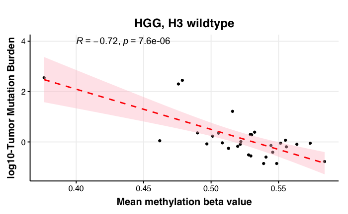

```r
tmb <- read_tsv(tmb_file) %>%
  dplyr::rename(Kids_First_Biospecimen_ID_tumor = Tumor_Sample_Barcode)
methyl <- methyl %>%
  left_join(tmb %>% dplyr::select(Kids_First_Biospecimen_ID_tumor,
                                  tmb)) %>%
    distinct(Kids_First_Biospecimen_ID_normal, .keep_all = TRUE)
methyl %>%
  dplyr::filter(plot_group == "Other high-grade glioma",
                grepl("H3 wildtype", molecular_subtype)) %>%
  ggplot(aes(x = mean_beta_value, y = log10(tmb))) +
       geom_point() +
       stat_smooth(method = "lm", formula = y ~ x,
                   geom = "smooth", colour = "red",
                   fill = "pink", linetype="dashed") +
       labs(x = "Mean methylation beta value",
            y = "log10-Tumor Mutation Burden",
            title = "HGG, H3 wildtype") +
       stat_cor(method = "pearson",
                label.x = 0.4, label.y = 4, size = 5) +
       theme_Publication()

ggsave(file.path(plot_dir, "tmb-vs-mean-beta-methylation-hgg-h3-wt.pdf"),
       width = 5, height = 5)
```

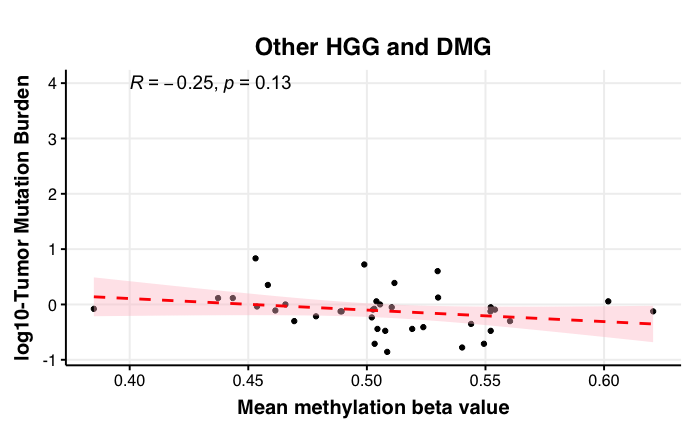

```r
methyl %>%
  dplyr::filter(plot_group %in% c("Other high-grade glioma", "DIPG or DMG"),
                !grepl("H3 wildtype", molecular_subtype)) %>%
  ggplot(aes(x = mean_beta_value, y = log10(tmb))) +
       geom_point() +
       stat_smooth(method = "lm", formula = y ~ x,
                   geom = "smooth", colour = "red",
                   fill = "pink", linetype="dashed") +
       labs(x = "Mean methylation beta value",
            y = "log10-Tumor Mutation Burden",
            title = "Other HGG and DMG") +
       stat_cor(method = "pearson",
                label.x = 0.4, label.y = 4, size = 5) +
       theme_Publication()

ggsave(file.path(plot_dir, "tmb-vs-mean-beta-methylation-hgg-h3-mutant.pdf"),
       width = 5, height = 5)
```

Calculate pearson correlation coefficients between TMB and global methylation in each tumor histology

```r
cor_df <- data.frame(plot_group = unique(methyl$plot_group),
                     pearson_r = 0,
                     pearson_p = 0)

for (i in 1:nrow(cor_df)){

  group = cor_df$plot_group[i]

  cor_test <- cor.test(log10(methyl$tmb[methyl$plot_group == group]),
                       methyl$mean_beta_value[methyl$plot_group == group],
                       method = "pearson")

  cor_df$pearson_r[i] <- cor_test$estimate
  cor_df$pearson_p[i] <- cor_test$p.value

}

write_tsv(cor_df,
          file.path(results_dir, "tmb-methylation-correlation-by-hist.tsv"))
```